# Task01

Andronik Ordian

# Theory

## 2.1

### Coins

Мелочь = $\beta_0$ + $\beta_1 \cdot$ #{1, 5, 10-копеечных монет} + $\beta_2 \cdot$ #{всего монет}

Коэффициент $\beta_2$ будет положителен, т.к. несмотря на зависимость $X_1$ и $X_2$, имеются монеты с бОльшим достоинством.

### Football

Отрицательный коэффициет при высоте может означать, что рост и вес у спортсменов сильно зависимы.

## 2.2

$RSS = (y_1 - \hat{\beta_0} - \hat{\beta_1}x_1)^2 + \ldots + (y_n - \hat{\beta_0} - \hat{\beta_1}x_n)^2$ Продифференцируем $RSS$ по $\beta_0$ и приравняем к нулю $\frac{1}{n}(y_1 - \hat{\beta_0} - \hat{\beta_1}x_1) + \ldots +\frac{1}{n} (y_n - \hat{\beta_0} - \hat{\beta_1}x_n) = 0$ Отсюда $\hat{\beta_0} = \bar{y} - \hat{\beta_1}\bar{x}$ Продифференцируем $RSS$ по $\beta_1$, приравняем к нулю и вычтем $n\bar{x}$ раз уравнение для $\beta_0$ $(y_1 - (\bar{y} - \hat{\beta_1}\bar{x}) - \hat{\beta_1}x_1)(x_1 - \bar{x}) + \ldots + (y_n - (\bar{y} - \hat{\beta_1}\bar{x}) - \hat{\beta_1}x_n)(x_n - \bar{x}) = 0$ Отсюда $\hat{\beta_1} = \frac{\sum (x_i -\bar{x}) (y_i - \bar{y})}{\sum (x_i - \bar{x})^2}$

## 2.3

### 1

Гипотезу $H_0 : \beta_{TV} = \beta_{radio} = \beta_{newspaper} = 0$ можно смело отвергнуть, т.к. p-value на слайде 20 очень мало (по крайней мере для TV и radio). Поэтому связь есть.

### 2

Статистика $R^2$ (слайд 22) примерно равна $0.9$, т.е. предикторы объясняют примерно 90% дисперсии продаж.

### 3

Опять смотрим на p-value и видим, что влияние оказывают TV и radio, но при затратах на эти виды рекламы, вклад в newspaper уже не оправдывает себя.

### 4

Нет. Смотрим на слайд 19 и видим, что наша модель переоценивает продажы, когда бюджет был потрачен на один вид рекламы и недооценивает его, когда он был распилен пополам. Это как бы намекает на взаимное влияние между разными видами рекламы.

### 5

Да, слайд 37 лекции 3. Между TV и radio (p-value мало).

# Practice

## 3.1

```r
library(lattice)
library(MASS)

Advertising <- read.csv("Advertising.csv")
Advertising$X <- NULL
summary(Advertising)
```

```
##        TV             Radio          Newspaper          Sales
##  Min.   :  0.70   Min.   : 0.000   Min.   :  0.30   Min.   : 1.60
##  1st Qu.: 74.38   1st Qu.: 9.975   1st Qu.: 12.75   1st Qu.:10.38
##  Median :149.75   Median :22.900   Median : 25.75   Median :12.90
##  Mean   :147.04   Mean   :23.264   Mean   : 30.55   Mean   :14.02
##  3rd Qu.:218.82   3rd Qu.:36.525   3rd Qu.: 45.10   3rd Qu.:17.40
##  Max.   :296.40   Max.   :49.600   Max.   :114.00   Max.   :27.00
```

scatterplot

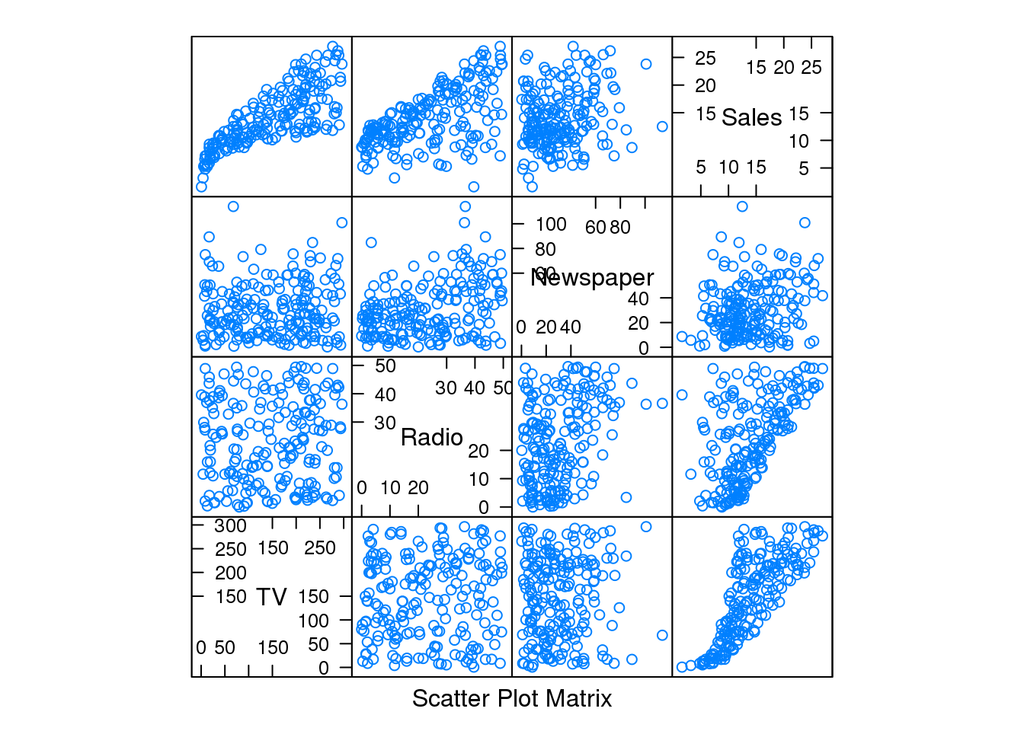

```r
splom(~Advertising)
```

Мы уже знаем о взаимном влиянии признаков. Построим регрессию второго порядка

```r
Advertising.lm.square <- lm(Sales ~ poly(TV, Radio, Newspaper, degree = 2), data = Advertising)
```

AIC summary

```r
summary(stepAIC(Advertising.lm.square))
```

```
## Start:  AIC=-181.3
## Sales ~ poly(TV, Radio, Newspaper, degree = 2)
##
##                                          Df Sum of Sq    RSS    AIC
## <none>                                                  73.1 -181.3
## - poly(TV, Radio, Newspaper, degree = 2)  9      5344 5417.1  661.8
```

```
##
## Call:
## lm(formula = Sales ~ poly(TV, Radio, Newspaper, degree = 2),
##     data = Advertising)
##
## Residuals:
##     Min      1Q  Median      3Q     Max
## -4.6507 -0.2941 -0.0060  0.3830  1.4378
##
## Coefficients:
##                                              Estimate Std. Error t value
## (Intercept)                                  13.94105    0.04806 290.083
## poly(TV, Radio, Newspaper, degree = 2)1.0.0  53.73032    0.62580  85.858
## poly(TV, Radio, Newspaper, degree = 2)2.0.0  -9.97989    0.63251 -15.778
## poly(TV, Radio, Newspaper, degree = 2)0.1.0  40.10484    0.67044  59.819
## poly(TV, Radio, Newspaper, degree = 2)1.1.0 280.35751    9.65318  29.043
## poly(TV, Radio, Newspaper, degree = 2)0.2.0   0.29727    0.64859   0.458
## poly(TV, Radio, Newspaper, degree = 2)0.0.1   0.94373    0.74141   1.273
## poly(TV, Radio, Newspaper, degree = 2)1.0.1 -16.93577    8.84414  -1.915
## poly(TV, Radio, Newspaper, degree = 2)0.1.1   5.31882   10.95328   0.486
## poly(TV, Radio, Newspaper, degree = 2)0.0.2   0.10711    0.65997   0.162
##                                             Pr(>|t|)
## (Intercept)                                   <2e-16 ***
## poly(TV, Radio, Newspaper, degree = 2)1.0.0   <2e-16 ***
## poly(TV, Radio, Newspaper, degree = 2)2.0.0   <2e-16 ***
## poly(TV, Radio, Newspaper, degree = 2)0.1.0   <2e-16 ***
## poly(TV, Radio, Newspaper, degree = 2)1.1.0   <2e-16 ***
## poly(TV, Radio, Newspaper, degree = 2)0.2.0    0.647
## poly(TV, Radio, Newspaper, degree = 2)0.0.1    0.205
## poly(TV, Radio, Newspaper, degree = 2)1.0.1    0.057 .
## poly(TV, Radio, Newspaper, degree = 2)0.1.1    0.628
## poly(TV, Radio, Newspaper, degree = 2)0.0.2    0.871
## ---
## Signif. codes:  0 '***' 0.001 '**' 0.01 '*' 0.05 '.' 0.1 ' ' 1
##
## Residual standard error: 0.6203 on 190 degrees of freedom
## Multiple R-squared:  0.9865, Adjusted R-squared:  0.9859
## F-statistic:  1543 on 9 and 190 DF,  p-value: < 2.2e-16
```

Акаике намекает, что нужно оставить $TV$, $TV^2$, $Radio$, $TV \times Radio$.

test/train

```r
train.idx <- sample(nrow(Advertising), size = nrow(Advertising) * 2/3)
Advertising.train <- Advertising[train.idx, ]
Advertising.test <- Advertising[-train.idx, ]

Advertising.lm.train <- lm(Sales ~ TV + I(TV^2) + Radio + TV:Radio, data = Advertising.train)
```

Посмотрим на ошибки

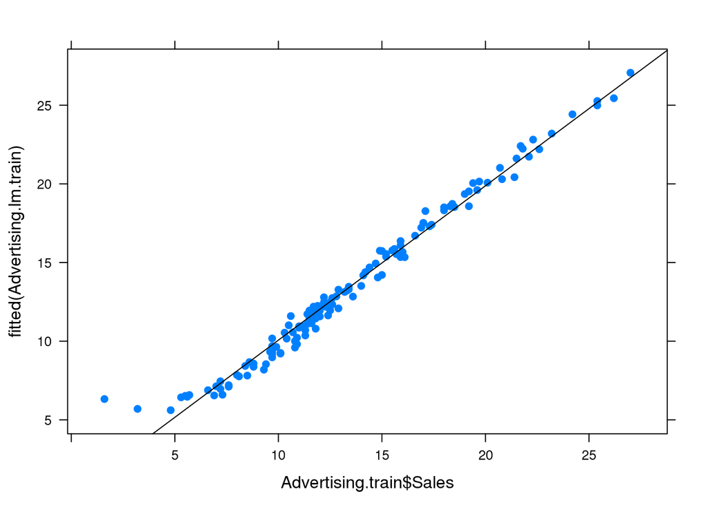

```r
panel <- function(...) {
  panel.xyplot(...)
  panel.lmline(...)
}
xyplot(fitted(Advertising.lm.train) ~ Advertising.train$Sales, panel = panel, pch = 19)
```

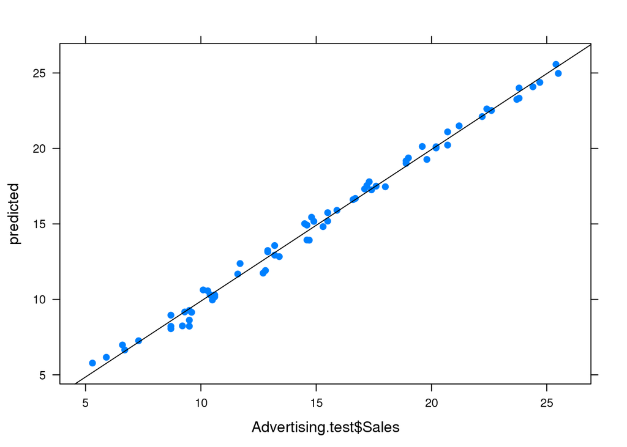

```r
predicted <- predict(Advertising.lm.train, Advertising.test)
xyplot(predicted ~ Advertising.test$Sales, panel = panel, pch = 19)
```

Ошибки невелики, но при малых Sales мы склонны к излишнему оптимистизму. Вычисляем среднюю ошибку в смысле RSE для нашей модели.

```r
RSE <- function(train, predicted) {
  rse <- function(r) sqrt(sum(r ^ 2) / (length(r) - train$rank))
  c(rse(train$residuals), rse(predicted - Advertising.test$Sales))
}

RSE(Advertising.lm.train, predicted)
```

```
## [1] 0.7033225 0.4738444
```

Теперь для обычной модели.

```r
train <- lm(Sales ~ ., data = Advertising)

RSE(train, predict(train, Advertising.test))
```

```
## [1] 1.685510 1.553353
```

Очевидно, наша модель лучше.

Выкинем газеты из обычной модели

```r
noNewspaper <- update(train, ~ . -Newspaper)
RSE(noNewspaper, predict(noNewspaper, Advertising.test))
```

```
## [1] 1.681361 1.543300
```

Вроде норм. Удалим теперь радио.

```r
noRadio <- update(train, . ~ . -Radio)
RSE(noRadio, predict(noRadio, Advertising.test))
```

```
## [1] 3.120720 3.292204
```

Уже не норм. Признак значимый. Удалим всё, кроме сдвига.

```r
onlyIntercept <- update(train, . ~ . -Radio -TV - Newspaper)
RSE(onlyIntercept, predict(onlyIntercept, Advertising.test))
```

```
## [1] 5.217457 5.550069
```

Совсем не норм.

Попробуем теперь другие степени TV.

```r
library(e1071)
perf <- function (formula) {
  mean(replicate(50, tune(lm, formula,
    data = Advertising,
    tunecontrol = tune.control(sampling = "fix"))$best.performance))
}
print(perf(Advertising.lm.train$call$formula))
```

```
## [1] 0.4489365
```

```r
print(perf(Sales ~ sqrt(TV) * Radio))
```

```
## [1] 0.2217283
```

```r
print(perf(Sales ~ log(TV) + I(TV * Radio) + Radio - 1))
```

```
## [1] 0.09544723
```

```r
summary(stepAIC(lm(Sales ~ log(TV) + I(TV * Radio) + Radio - 1, data = Advertising)))
```

```
## Start:  AIC=-473.52
## Sales ~ log(TV) + I(TV * Radio) + Radio - 1
##
##                 Df Sum of Sq    RSS     AIC
## <none>                         18.2 -473.52
## - Radio          1      70.8   89.0 -157.99
## - I(TV * Radio)  1    1146.6 1164.8  356.40
## - log(TV)        1    5474.1 5492.3  666.56
```

```
##
## Call:
## lm(formula = Sales ~ log(TV) + I(TV * Radio) + Radio - 1, data = Advertising)
##
## Residuals:
##     Min      1Q  Median      3Q     Max
## -0.8702 -0.2226  0.0209  0.1929  0.7620
##
## Coefficients:
##                Estimate Std. Error t value Pr(>|t|)
## log(TV)       2.005e+00  8.233e-03  243.51   <2e-16 ***
## I(TV * Radio) 1.013e-03  9.092e-06  111.45   <2e-16 ***
## Radio         4.801e-02  1.734e-03   27.69   <2e-16 ***
## ---
## Signif. codes:  0 '***' 0.001 '**' 0.01 '*' 0.05 '.' 0.1 ' ' 1
##
## Residual standard error: 0.3038 on 197 degrees of freedom
## Multiple R-squared:  0.9996, Adjusted R-squared:  0.9996
## F-statistic: 1.615e+05 on 3 and 197 DF,  p-value: < 2.2e-16
```

Посмотрим на ошибки

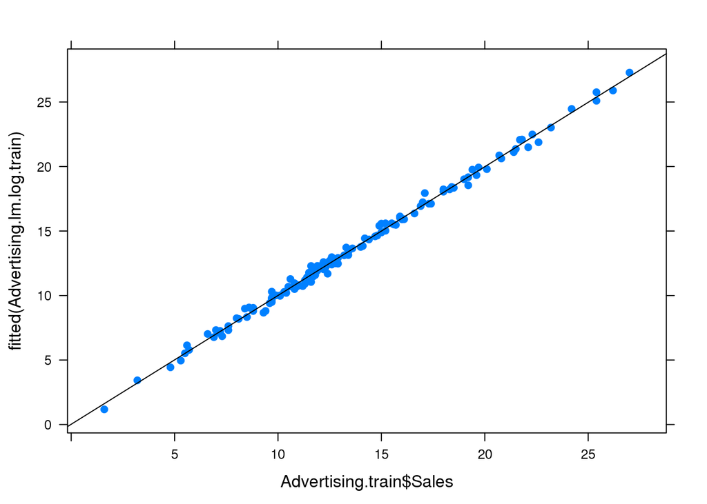

```r
Advertising.lm.log.train <- lm(Sales ~ log(TV) + I(TV * Radio) + Radio - 1, data = Advertising.train)
xyplot(fitted(Advertising.lm.log.train) ~ Advertising.train$Sales, panel = panel, pch = 19)
```

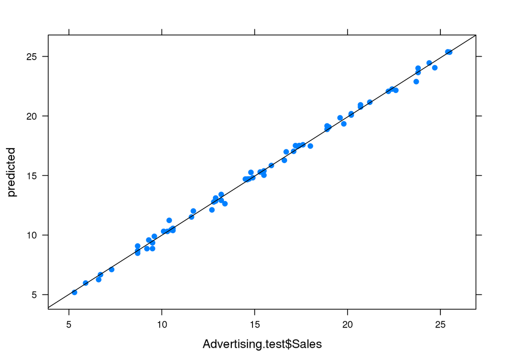

```r
predicted <- predict(Advertising.lm.log.train, Advertising.test)
xyplot(predicted ~ Advertising.test$Sales, panel = panel, pch = 19)
```

Победил логарифм.